# MATISSE

a MATLAB Toolbox for vItal rateS Surveillance

September 28, 2026

Modified

September 28, 2026

A MATLAB TOOLBOX FOR VITAL RATES SURVEILLANCE

## Explore cancer rates. Model age, period, and cohort.

MATISSE is an advanced age-period-cohort (APC) modeling toolbox for vital rates surveillance. It provides all the outputs of the NCI web tool and adds smoothing, semiparametric, and comparative methods.

For epidemiologists, cancer registry researchers, and biostatisticians.

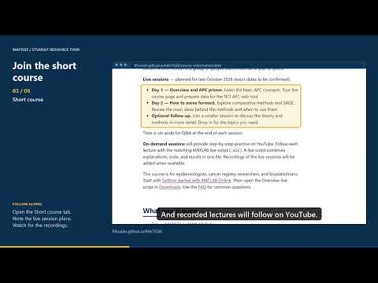

**Welcome to MATISSE**Watch the MATISSE tour on YouTube ↗

## What MATISSE can do

- Fit the new APC model and read its six estimable functions.
- Draw standard plots and Lexis diagrams of your rates.
- Smooth noisy rates with SIFT and fit SAGE models.
- Compare APC results across groups.

START HERE

## Your learning path

Watch → Read → Run the code

Work through the four steps in order, or jump to the one you need. Open a step to find its videos, slides, and practice task. Resource links open in a new tab.

**01**Getting started with APC modeling**Learn the basics of age-period-cohort modeling.+**

Learn the basics

WATCH · COMING SOONWhat APC modeling is for, and why epidemiologists use it

READ · SLIDESStatistical methods in cancer surveillance ↗READ · METHODS PAPERAdvances in cancer surveillance methods ↗

Where to start

READ · SLIDESExtract SEER and CI5 Plus data ↗[RUN · NCI WEB TOOLRun APC modeling with the NCI web tool ↗](https://analysistools.cancer.gov/apc/)

**Where to start: prepare your data**

The NCI web tool needs an input matrix of case counts and population by age group and calendar period. Age and period intervals must be equal in width, so 5-year age groups need 5-year periods. No count or population cell can be zero. The slides above show how to build this matrix from SEER*Stat (US data) or from the CI5 Plus database. Then run your analysis in the web tool.

[analysistools.cancer.gov/apc ↗](https://analysistools.cancer.gov/apc/)

**02**What is MATISSE?**MATISSE is an advanced APC modeling toolbox for vital rates surveillance.+**

[WATCH · 2:08MATISSE tour ↗](https://www.youtube.com/watch?v=CLSP755kp4I)LIVE COURSEShort course: format and schedule →

Why MATISSE?

**Want higher-resolution results?**

MATISSE can interpolate 5-year age groups to 1-year age groups. Run `help rates/i5` to see how.

**Want to smooth the data?**

SIFT smooths a matrix of rates. SAGE then fits the APC model to the smoothed rates. See the examples →

**Want to compare modeled results?**

Comparative APC methods test whether rates from several groups share the same patterns. See the example →

**Join the short course**

Live sessions are planned for late October 2026 (dates to be confirmed). Read about the format, the schedule, and the team.

Short course details →

**03**How to use MATISSE?**Getting started with the toolbox+**

Set up

READ · MATLAB GUIDESet up MATLAB Online →DOWNLOADMATISSE toolbox ↗[OPENOverview live script in MATLAB Online ↗](https://matlab.mathworks.com/open/github/v1?repo=filhoalm/MATISSE&file=downloads/MATISSE_1_Overview.mlx)

Meet the toolbox

[WATCH · 0:22System map guide ↗](https://www.youtube.com/watch?v=6frwitiOJ_Y)READ · SLIDESStatistical methods in cancer surveillance ↗RUN · LIVE SCRIPTMATISSE 1 Overview ↗

Explore Lexis diagrams

[WATCH · 0:43Visualizing a Lexis diagram ↗](https://www.youtube.com/watch?v=dzQgEBVj48o)READ · SLIDESThe Lexis Diagram ↗RUN · LIVE SCRIPTMATISSE 2 The Lexis Diagram ↗

Examples and resources

EXAMPLESWorked examples with live scripts →RESOURCESDownloads, papers, and FAQ →

The examples cover the 4 standard plots, Lexis diagrams, and the 6 estimable functions. Advanced methods have their own short examples.

**Try it in MATLAB**

Open MATLAB Online, unzip the toolbox, and add its folder and subfolders to the MATLAB path. Run the Overview live script one section at a time. Open the system map with `matisse('map')`, then load the example data and draw a heat map with `pcolor`.

Read about the system map →

**04**Advanced theory and analysis**Uncover the theory of MATISSE and perform advanced analyses such as SIFT, SAGE, and comparative APC.+**

Theory and videos

READ · SLIDES · COMING SOONTheory and statistical formulas

[WATCH · YOUTUBE CHANNELMATISSE on YouTube: on-demand lectures ↗](https://www.youtube.com/@filhoam)

Method papers

[APC MODELThe new age-period-cohort model ↗](https://journals.sagepub.com/doi/10.1177/0962280218801121)[SIFTSmoothing methods for Lexis diagrams ↗](https://journals.sagepub.com/doi/10.1177/09622802231192950)[SAGESemiparametric APC analysis ↗](https://jamanetwork.com/journals/jamanetworkopen/fullarticle/2819747)[COMPARATIVE APCComparative APC analysis ↗](https://link.springer.com/article/10.1186/s12874-023-02039-8)

**Try an advanced method**

Choose SIFT to smooth noisy rates, SAGE to fit the APC model to smoothed rates, or comparative APC to compare groups. Read the short description, then open the method paper.

See the advanced examples →

**Have a question?**

Send us an email at matisse.apc@gmail.com

Email us →

## Team

- **Philip S. Rosenberg**
- **Hyuna Sung**
- **Kieran Kelly**
- **Chenxi Jiang**
- **Adalberto M. Filho**
- **Yasmmin Martins**

Philip S. Rosenberg, PhD, developed the MATISSE toolbox and its code. The toolbox implements methods developed with the cancer surveillance research community. These include the APC methods described in Filho & Rosenberg, Front Oncol 2024. The team listed above develops the course.

## FAQ

**Do I need to buy MATLAB to use MATISSE?**

You can use MATLAB Online in your browser. Sign in with a MathWorks account and check the current access terms. Follow Getting started with MATLAB Online to set up the toolbox. You need a MATLAB license to use a local copy.

**Do I need to know MATLAB already?**

Some familiarity helps. Start with the Overview live script to learn how the toolbox works. Run one section at a time and inspect the result. Use Getting help when a command is unfamiliar.

**Is MATISSE peer reviewed / published?**

The methods are described in Filho & Rosenberg, *Advances in statistical methods for cancer surveillance research: an age-period-cohort perspective* (Front Oncol, 2024). Download the paper from Downloads. For individual methods, such as SAGE and comparative APC analysis, open Related methods and publications.

**How do I ask a question or get help?**

Send us an email at matisse.apc@gmail.com. For quick answers about commands, use the toolbox's built-in help. See Getting help for the commands.

**Will the live sessions be recorded?**

Yes. Recordings will be linked here when they are available.